# Forecasting renewable energy generation from wind farms and the impact on CO2 emission reduction.

The-Data-Minds

2026-04-16

## Introduction

This study investigates the impact of wind energy generation on carbon intensity in the electricity sector. It further examines the extent to which wind energy can substitute fossil fuel-based generation and evaluates potential reductions in carbon intensity under different wind expansion scenarios.

## 1. Load Libraries & Data

```r
library(tidyverse)
library(Metrics)
library(randomForest)
library(xgboost)
library(e1071)
```

```r
df_fuel_ckan <- read_csv("df_fuel_ckan.csv")
```

Relevant libraries were loaded for data manipulation, statistical analysis, visualisation, and modelling.

### Dataset inspection

```r
head(df_fuel_ckan)
```

```
## # A tibble: 6 × 34
##   DATETIME              GAS  COAL NUCLEAR  WIND WIND_EMB HYDRO IMPORTS BIOMASS
##   <dttm>              <dbl> <dbl>   <dbl> <dbl>    <dbl> <dbl>   <dbl>   <dbl>
## 1 2009-01-01 00:00:00  8367 15037    7099   248       62   246    2518       0
## 2 2009-01-01 00:30:00  8495 15095    7088   229       57   245    2495       0
## 3 2009-01-01 01:00:00  8471 15088    7074   207       52   246    2465       0
## 4 2009-01-01 01:30:00  8318 15035    7064   191       48   246    2439       0
## 5 2009-01-01 02:00:00  8295 15005    7052   175       44   246    2363       0
## 6 2009-01-01 02:30:00  8304 15018    7041   162       40   236    2336       0
## # ℹ 25 more variables: OTHER <dbl>, SOLAR <dbl>, STORAGE <dbl>,
## #   GENERATION <dbl>, CARBON_INTENSITY <dbl>, LOW_CARBON <dbl>,
## #   ZERO_CARBON <dbl>, RENEWABLE <dbl>, FOSSIL <dbl>, GAS_perc <dbl>,
## #   COAL_perc <dbl>, NUCLEAR_perc <dbl>, WIND_perc <dbl>, WIND_EMB_perc <dbl>,
## #   HYDRO_perc <dbl>, IMPORTS_perc <dbl>, BIOMASS_perc <dbl>, OTHER_perc <dbl>,
## #   SOLAR_perc <dbl>, STORAGE_perc <dbl>, GENERATION_perc <dbl>,
## #   LOW_CARBON_perc <dbl>, ZERO_CARBON_perc <dbl>, RENEWABLE_perc <dbl>, …
```

The output displays the first six rows of the dataset, showing actual values for variables such as wind, gas, coal, and carbon intensity.

```r
str(df_fuel_ckan)
```

```
## spc_tbl_ [303,019 × 34] (S3: spec_tbl_df/tbl_df/tbl/data.frame)
##  $ DATETIME        : POSIXct[1:303019], format: "2009-01-01 00:00:00" "2009-01-01 00:30:00" ...
##  $ GAS             : num [1:303019] 8367 8495 8471 8318 8295 ...
##  $ COAL            : num [1:303019] 15037 15095 15088 15035 15005 ...
##  $ NUCLEAR         : num [1:303019] 7099 7088 7074 7064 7052 ...
##  $ WIND            : num [1:303019] 248 229 207 191 175 162 155 143 132 124 ...
##  $ WIND_EMB        : num [1:303019] 62 57 52 48 44 40 39 36 33 31 ...
##  $ HYDRO           : num [1:303019] 246 245 246 246 246 236 226 225 225 224 ...
##  $ IMPORTS         : num [1:303019] 2518 2495 2465 2439 2363 ...
##  $ BIOMASS         : num [1:303019] 0 0 0 0 0 0 0 0 0 0 ...
##  $ OTHER           : num [1:303019] 0 0 0 0 0 0 0 0 0 0 ...
##  $ SOLAR           : num [1:303019] 0 0 0 0 0 0 0 0 0 0 ...
##  $ STORAGE         : num [1:303019] 0 0 0 0 0 0 0 0 0 0 ...
##  $ GENERATION      : num [1:303019] 33577 33704 33603 33340 33179 ...
##  $ CARBON_INTENSITY: num [1:303019] 524 526 527 527 528 529 531 531 534 535 ...
##  $ LOW_CARBON      : num [1:303019] 7655 7618 7578 7549 7517 ...
##  $ ZERO_CARBON     : num [1:303019] 7593 7561 7527 7501 7473 ...
##  $ RENEWABLE       : num [1:303019] 556 531 504 484 465 438 420 404 390 379 ...
##  $ FOSSIL          : num [1:303019] 23404 23590 23560 23352 23299 ...
##  $ GAS_perc        : num [1:303019] 24.9 25.2 25.2 24.9 25 25.1 25.3 25.3 26 26.5 ...
##  $ COAL_perc       : num [1:303019] 44.8 44.8 44.9 45.1 45.2 45.3 45.5 45.5 45.7 45.6 ...
##  $ NUCLEAR_perc    : num [1:303019] 21.1 21 21.1 21.2 21.3 21.2 21.3 21.4 21.3 21.1 ...
##  $ WIND_perc       : num [1:303019] 0.7 0.7 0.6 0.6 0.5 0.5 0.5 0.4 0.4 0.4 ...
##  $ WIND_EMB_perc   : num [1:303019] 0.2 0.2 0.2 0.1 0.1 0.1 0.1 0.1 0.1 0.1 ...
##  $ HYDRO_perc      : num [1:303019] 0.7 0.7 0.7 0.7 0.7 0.7 0.7 0.7 0.7 0.7 ...
##  $ IMPORTS_perc    : num [1:303019] 7.5 7.4 7.3 7.3 7.1 7.1 6.7 6.6 5.9 5.7 ...
##  $ BIOMASS_perc    : num [1:303019] 0 0 0 0 0 0 0 0 0 0 ...
##  $ OTHER_perc      : num [1:303019] 0 0 0 0 0 0 0 0 0 0 ...
##  $ SOLAR_perc      : num [1:303019] 0 0 0 0 0 0 0 0 0 0 ...
##  $ STORAGE_perc    : num [1:303019] 0 0 0 0 0 0 0 0 0 0 ...
##  $ GENERATION_perc : num [1:303019] 100 100 100 100 100 100 100 100 100 100 ...
##  $ LOW_CARBON_perc : num [1:303019] 22.8 22.6 22.6 22.6 22.7 22.6 22.6 22.6 22.5 22.2 ...
##  $ ZERO_CARBON_perc: num [1:303019] 24.5 24.3 24.2 24.3 24.3 24.2 24.1 24.1 23.8 23.5 ...
##  $ RENEWABLE_perc  : num [1:303019] 1.7 1.6 1.5 1.5 1.4 1.3 1.3 1.2 1.2 1.1 ...
##  $ FOSSIL_perc     : num [1:303019] 69.7 70 70.1 70 70.2 70.4 70.8 70.8 71.7 72.1 ...
##  - attr(*, "spec")=
##   .. cols(
##   ..   DATETIME = col_datetime(format = ""),
##   ..   GAS = col_double(),
##   ..   COAL = col_double(),
```

[output cut: 18 more lines]

```
##   ..   WIND_perc = col_double(),
##   ..   WIND_EMB_perc = col_double(),
##   ..   HYDRO_perc = col_double(),
##   ..   IMPORTS_perc = col_double(),
##   ..   BIOMASS_perc = col_double(),
##   ..   OTHER_perc = col_double(),
##   ..   SOLAR_perc = col_double(),
##   ..   STORAGE_perc = col_double(),
##   ..   GENERATION_perc = col_double(),
##   ..   LOW_CARBON_perc = col_double(),
##   ..   ZERO_CARBON_perc = col_double(),
##   ..   RENEWABLE_perc = col_double(),
##   ..   FOSSIL_perc = col_double()
##   .. )
##  - attr(*, "problems")=<externalptr>
```

The dataset consists of over 300,000 observations with mostly numeric variables and a properly formatted datetime column, making it suitable for time-series analysis and modelling.

```r
summary(df_fuel_ckan)
```

```
##     DATETIME                        GAS             COAL          NUCLEAR
##  Min.   :2009-01-01 00:00:00   Min.   :  738   Min.   :    0   Min.   :2065
##  1st Qu.:2013-04-28 05:15:00   1st Qu.: 7416   1st Qu.:    0   1st Qu.:4987
##  Median :2017-08-23 10:30:00   Median :12014   Median : 1750   Median :6418
##  Mean   :2017-08-23 10:30:00   Mean   :11989   Mean   : 5459   Mean   :6257
##  3rd Qu.:2021-12-18 15:45:00   3rd Qu.:16309   3rd Qu.:10452   3rd Qu.:7553
##  Max.   :2026-04-14 21:00:00   Max.   :27868   Max.   :26044   Max.   :9342
##       WIND          WIND_EMB        HYDRO           IMPORTS
##  Min.   :    0   Min.   :   0   Min.   :   0.0   Min.   :   0
##  1st Qu.: 1009   1st Qu.: 301   1st Qu.: 192.0   1st Qu.:1420
##  Median : 2823   Median : 803   Median : 364.0   Median :2488
##  Mean   : 4104   Mean   :1089   Mean   : 395.7   Mean   :2567
##  3rd Qu.: 6002   3rd Qu.:1589   3rd Qu.: 562.0   3rd Qu.:3226
##  Max.   :18439   Max.   :5947   Max.   :1403.0   Max.   :9230
##     BIOMASS           OTHER          SOLAR            STORAGE
##  Min.   :   0.0   Min.   :   0   Min.   :    0.0   Min.   :   0
##  1st Qu.:   0.0   1st Qu.:  62   1st Qu.:    0.0   1st Qu.:   0
##  Median :   0.0   Median : 183   Median :    0.0   Median : 136
##  Mean   : 959.7   Mean   : 466   Mean   :  948.5   Mean   : 271
##  3rd Qu.:1993.0   3rd Qu.: 713   3rd Qu.:  898.0   3rd Qu.: 410
##  Max.   :3415.0   Max.   :3388   Max.   :14414.0   Max.   :2660
##    GENERATION    CARBON_INTENSITY   LOW_CARBON     ZERO_CARBON
##  Min.   :18365   Min.   : 19.0    Min.   : 4626   Min.   : 4614
##  1st Qu.:28969   1st Qu.:168.0    1st Qu.: 9819   1st Qu.: 9137
##  Median :34228   Median :254.0    Median :12820   Median :10971
##  Mean   :34506   Mean   :289.2    Mean   :14025   Mean   :11989
##  3rd Qu.:39513   3rd Qu.:429.0    3rd Qu.:17341   3rd Qu.:14173
##  Max.   :59577   Max.   :644.0    Max.   :39849   Max.   :27238
##    RENEWABLE         FOSSIL         GAS_perc       COAL_perc
##  Min.   :   21   Min.   :  854   Min.   : 1.80   Min.   : 0.00
##  1st Qu.: 2374   1st Qu.:10292   1st Qu.:23.80   1st Qu.: 0.00
##  Median : 5418   Median :16518   Median :35.10   Median : 4.90
##  Mean   : 6808   Mean   :17448   Mean   :34.19   Mean   :14.48
##  3rd Qu.: 9984   3rd Qu.:23641   3rd Qu.:44.70   3rd Qu.:29.70
##  Max.   :34309   Max.   :49096   Max.   :72.80   Max.   :60.60
##   NUCLEAR_perc     WIND_perc     WIND_EMB_perc      HYDRO_perc
##  Min.   : 4.90   Min.   : 0.00   Min.   : 0.000   Min.   :0.000
##  1st Qu.:14.70   1st Qu.: 2.90   1st Qu.: 0.900   1st Qu.:0.600
##  Median :18.10   Median : 8.50   Median : 2.400   Median :1.100
##  Mean   :18.75   Mean   :12.47   Mean   : 3.308   Mean   :1.128
```

[output cut: 8 more lines]

```
##  Max.   :38.50   Max.   :16.00   Max.   :10.300   Max.   :42.900
##   STORAGE_perc    GENERATION_perc LOW_CARBON_perc ZERO_CARBON_perc
##  Min.   :0.0000   Min.   :100     Min.   :11.90   Min.   :11.90
##  1st Qu.:0.0000   1st Qu.:100     1st Qu.:28.50   1st Qu.:28.70
##  Median :0.4000   Median :100     Median :39.20   Median :39.20
##  Mean   :0.6961   Mean   :100     Mean   :42.03   Mean   :43.36
##  3rd Qu.:1.1000   3rd Qu.:100     3rd Qu.:53.20   3rd Qu.:55.00
##  Max.   :7.9000   Max.   :100     Max.   :94.90   Max.   :96.70
##  RENEWABLE_perc  FOSSIL_perc
##  Min.   : 0.1   Min.   : 2.10
##  1st Qu.: 6.8   1st Qu.:34.30
##  Median :16.2   Median :50.10
##  Mean   :20.3   Mean   :48.67
##  3rd Qu.:30.0   3rd Qu.:64.60
##  Max.   :78.6   Max.   :88.00
```

The summary statistics reveal substantial variability across key variables in the dataset. Carbon intensity ranges from 19 to 644, with a mean of approximately 289, indicating significant fluctuations in emissions over time. Wind generation shows a wide range from 0 to 18,439, suggesting periods of both low and high wind availability. Fossil fuel sources, particularly coal and gas, also exhibit large variation, reflecting changes in energy demand and supply mix. Additionally, renewable sources such as solar and wind show increasing upper values, indicating their growing contribution to electricity generation. Overall, the data demonstrates a dynamic energy system with considerable variation across time.

## 2. Feature Engineering

```r
df_fuel_ckan <- df_fuel_ckan %>%
  mutate(
    year = format(DATETIME, "%Y"),
    month = format(DATETIME, "%m"),
    hour = format(DATETIME, "%H")
  )
```

Time-based features (year, month, hour) were extracted from the datetime variable to enable temporal analysis and improve model interpretability.

## 3. Exploratory Data Analysis (EDA)

### Diagram 01: Wind Distribution

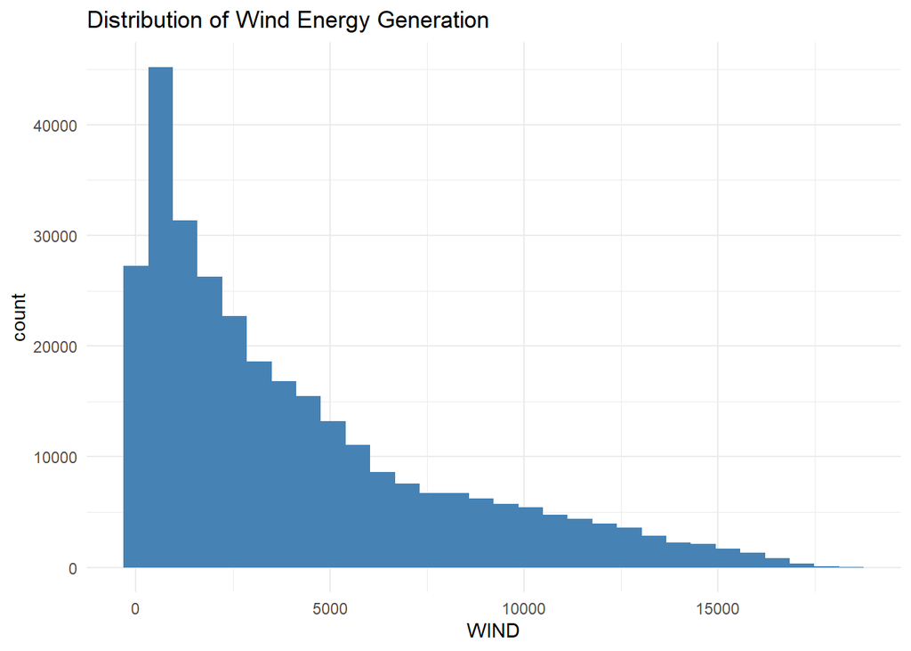

```r
ggplot(df_fuel_ckan, aes(x = WIND)) +
     geom_histogram(bins = 30, fill = "steelblue") +
     theme_minimal() +
     labs(title = "Distribution of Wind Energy Generation")
```

### Diagram 02: Distribution of Carbon Intensity

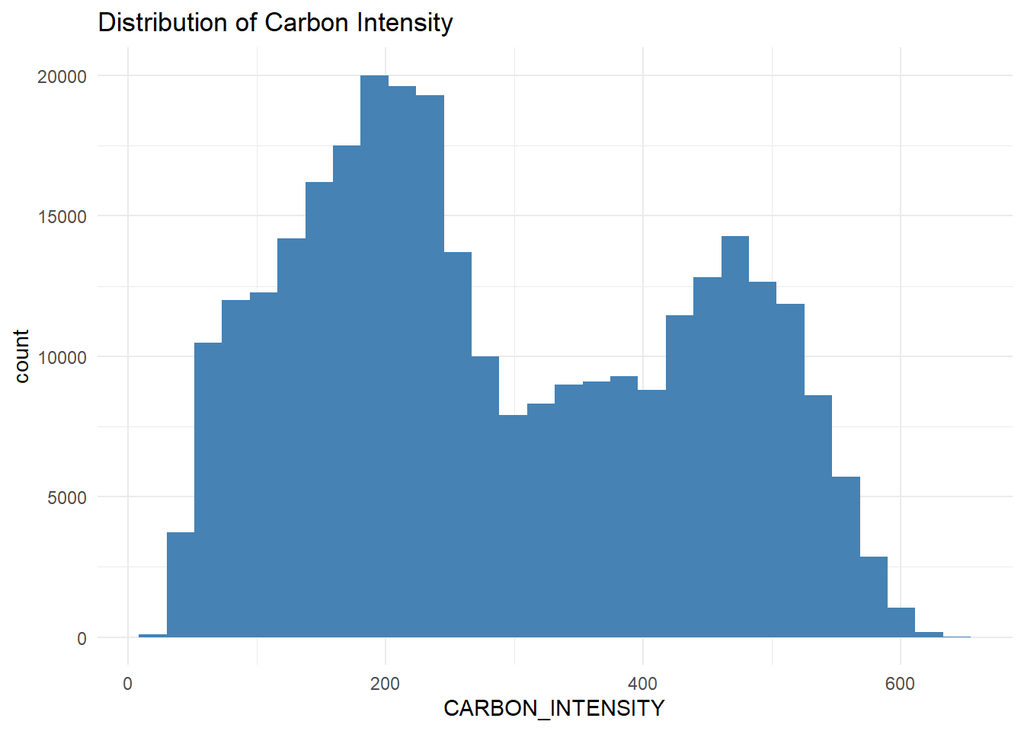

```r
ggplot(df_fuel_ckan, aes(x = CARBON_INTENSITY)) +
     geom_histogram(bins = 30, fill = "steelblue") +
     theme_minimal() +
     labs(title = "Distribution of Carbon Intensity")
```

The histogram shows that carbon intensity varies widely, reflecting changes in the energy mix over time.

### Diagram 03: Carbon intensity over time

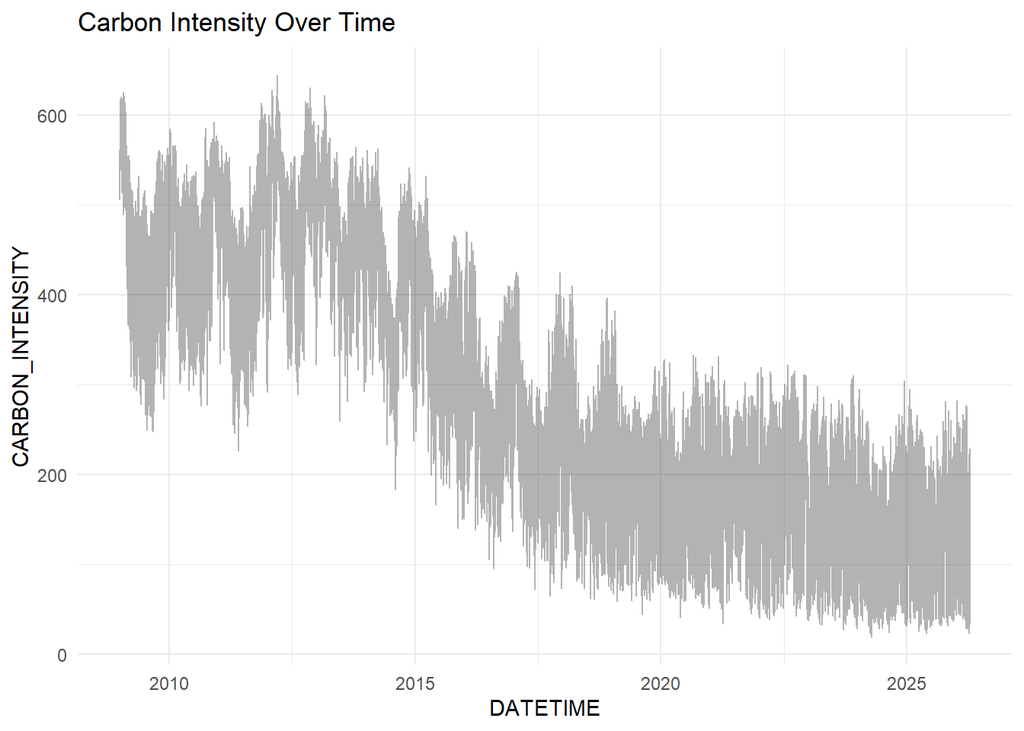

```r
 ggplot(df_fuel_ckan, aes(x = DATETIME, y = CARBON_INTENSITY)) +
    geom_line(alpha = 0.3) +
     theme_minimal() +
     labs(title = "Carbon Intensity Over Time")
```

EDA was conducted to examine the distribution of wind generation and carbon intensity, and to identify temporal trends. This provides initial insight into variability and potential patterns in the data.

The exploratory analysis shows wide variation in both wind generation and carbon intensity, pointing to a potentially strong link between renewable output and emissions. This pattern provides a solid basis for deeper statistical testing and modelling to quantify the strength of that relationship.

## Diagram 04:

### 4. RQ1 To what extent does wind energy generation influence carbon intensity in the electricity sector?

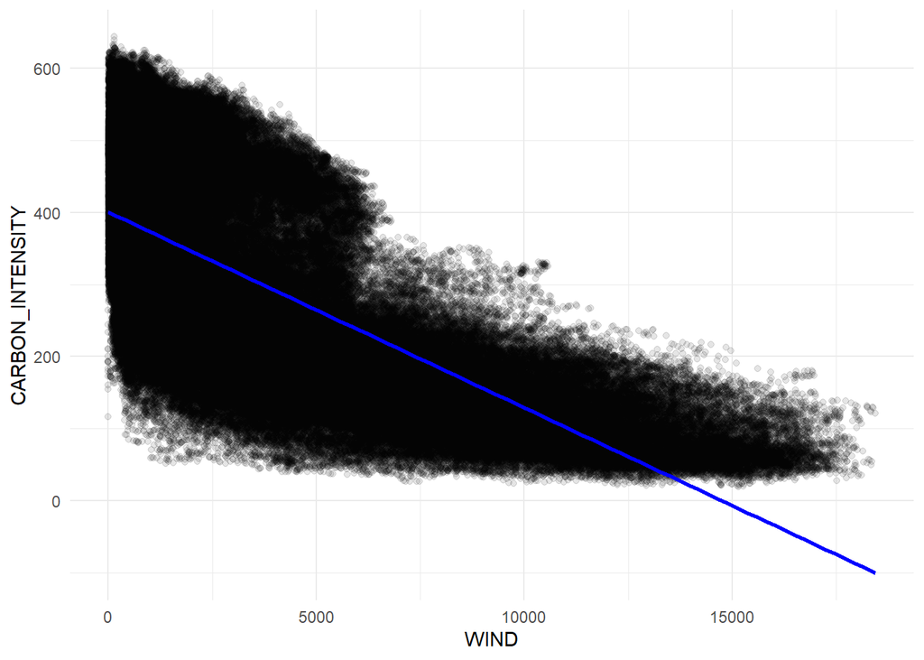

```r
ggplot(df_fuel_ckan, aes(x = WIND, y = CARBON_INTENSITY)) +
  geom_point(alpha = 0.1) +
  geom_smooth(method = "lm", color = "blue") +
  theme_minimal()
```

```r
cor(df_fuel_ckan[, c("WIND", "SOLAR", "COAL", "GAS", "CARBON_INTENSITY")])
```

```
##                        WIND       SOLAR       COAL         GAS CARBON_INTENSITY
## WIND              1.0000000  0.10039813 -0.4956500 -0.42317746       -0.7048579
## SOLAR             0.1003981  1.00000000 -0.3007830 -0.05817175       -0.3581254
## COAL             -0.4956500 -0.30078301  1.0000000  0.17978891        0.9252782
## GAS              -0.4231775 -0.05817175  0.1797889  1.00000000        0.3654796
## CARBON_INTENSITY -0.7048579 -0.35812541  0.9252782  0.36547958        1.0000000
```

The analysis demonstrates a strong relationship between wind energy generation and carbon intensity. Correlation results show a substantial negative association (-0.705), indicating that increases in wind generation are linked to significant reductions in carbon intensity. This is further supported by scatterplots, which reveal a clear downward trend, and boxplots, which show progressively lower carbon intensity across higher wind categories.These findings shows that wind energy plays a vital role in carbon emission reduction, with strong and consistent inverse relationship between wind generation and carbon intensity across all analytical approaches.

## Diagram 5&6:

### 5. RQ2 To what extent can electricity generated by wind farms replace coal- and gas-fired power generation over time?

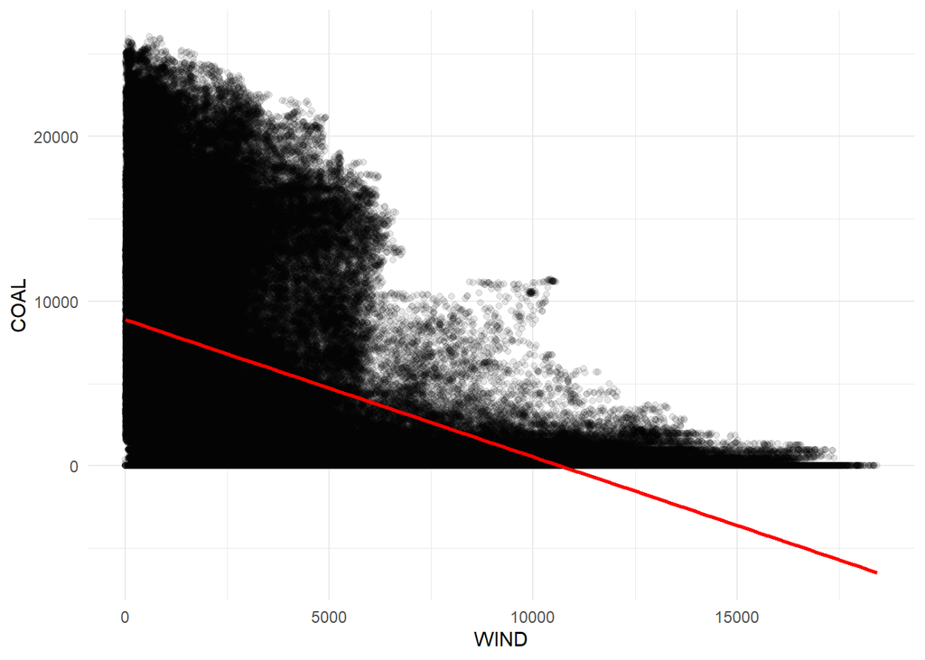

```r
ggplot(df_fuel_ckan, aes(x = WIND, y = COAL)) +
  geom_point(alpha = 0.1) +
  geom_smooth(method = "lm", color = "red") +
  theme_minimal()
```

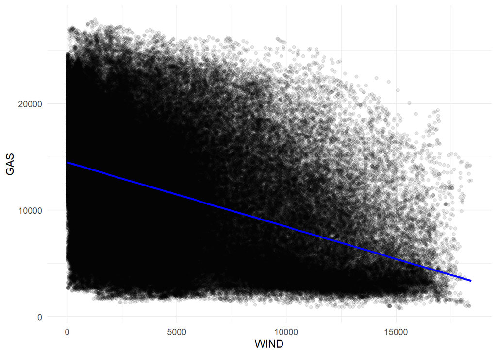

```r
ggplot(df_fuel_ckan, aes(x = WIND, y = GAS)) +
  geom_point(alpha = 0.1) +
  geom_smooth(method = "lm", color = "blue") +
  theme_minimal()
```

```r
cor(df_fuel_ckan[, c("WIND", "SOLAR", "COAL", "GAS", "CARBON_INTENSITY")])
```

```
##                        WIND       SOLAR       COAL         GAS CARBON_INTENSITY
## WIND              1.0000000  0.10039813 -0.4956500 -0.42317746       -0.7048579
## SOLAR             0.1003981  1.00000000 -0.3007830 -0.05817175       -0.3581254
## COAL             -0.4956500 -0.30078301  1.0000000  0.17978891        0.9252782
## GAS              -0.4231775 -0.05817175  0.1797889  1.00000000        0.3654796
## CARBON_INTENSITY -0.7048579 -0.35812541  0.9252782  0.36547958        1.0000000
```

The results provide clear evidence of a substitution effect: higher wind generation is linked to lower use of fossil fuel. The moderate negative correlation with coal (-o.496) and gas(-0.423) show that wind contributes to displacing these sources, especially coal. However, the strength of these relationships also makes it clear that wind alone cannot fully replace fossil fuel generation, underscoring the system’s ongoing structural dependence on conventional energy sources.

## 6. Categorisation for Statistical Test

```r
df_fuel_ckan <- df_fuel_ckan %>%
  mutate(
    WIND_CAT = cut(WIND,
                   breaks = quantile(WIND, probs = c(0, 0.33, 0.66, 1)),
                   labels = c("Low", "Medium", "High"),
                   include.lowest = TRUE),
    CARBON_CAT = cut(CARBON_INTENSITY,
                     breaks = quantile(CARBON_INTENSITY, probs = c(0, 0.33, 0.66, 1)),
                     labels = c("Low", "Medium", "High"),
                     include.lowest = TRUE)
  )
```

Continuous variables were categorised into quantiles to enable inferential statistical tests such as Chi-square and ANOVA.

## 7. Statistical Tests

```r
table_test <- table(df_fuel_ckan$WIND_CAT, df_fuel_ckan$CARBON_CAT)
chisq.test(table_test)
```

```
##
##  Pearson's Chi-squared test
##
## data:  table_test
## X-squared = 151493, df = 4, p-value < 2.2e-16
```

The Chi-square test result (X² = 151493, p-value < 2.2e-16) indicates a statistically significant association exist between wind generation levels and carbon intensity categories. Since the p-value is far below the 0.05 significance threshold, the null hypothesis of independence is rejected. This confirms that wind energy levels have a significant influence on carbon intensity.

```r
anova_model <- aov(CARBON_INTENSITY ~ WIND_CAT, data = df_fuel_ckan)
summary(anova_model)
```

```
##                 Df    Sum Sq   Mean Sq F value Pr(>F)
## WIND_CAT         2 3.207e+09 1.604e+09  136450 <2e-16 ***
## Residuals   303016 3.561e+09 1.175e+04
## ---
## Signif. codes:  0 '***' 0.001 '**' 0.01 '*' 0.05 '.' 0.1 ' ' 1
```

The ANOVA results show a clear and statistically significant difference in average carbon intensity across wind generation categories (F = 136450, p-value < 2e-16). Since the p-value is below the 0.05 threshold, the null hypothesis is rejected, indicating that wind generation levels, genuinely influence carbon intensity.

```r
TukeyHSD(anova_model)
```

```
##   Tukey multiple comparisons of means
##     95% family-wise confidence level
##
## Fit: aov(formula = CARBON_INTENSITY ~ WIND_CAT, data = df_fuel_ckan)
##
## $WIND_CAT
##                  diff       lwr       upr p adj
## Medium-Low  -107.3774 -108.5137 -106.2412     0
## High-Low    -250.3756 -251.5035 -249.2478     0
## High-Medium -142.9982 -144.1261 -141.8702     0
```

The Tukey test shows that all wind categories differ significantly, with carbon intensity decreasing consistently as wind generation increases. The largest reduction occurs between low and high wind levels, confirming a strong negative relationship.

## 8. Training & Testing Data Split (Time-Based)

```r
df_fuel_ckan <- df_fuel_ckan %>% arrange(DATETIME)

train <- df_fuel_ckan %>% filter(DATETIME < "2020-01-01")
test  <- df_fuel_ckan %>% filter(DATETIME >= "2020-01-01")
```

We split our dataset into training and testing using Date/time preserve the chronological order of the data. Unlike random splitting, this approach ensures that past data is used to predict future outcomes, which reflects real-world forecasting conditions. It also prevents data leakage, where information from the future could unintentionally influence the model. This is particularly important in energy data, where trends and patterns evolve over time.

## 9. Modelling

### linear regression

```r
model_lm <- lm(CARBON_INTENSITY ~ WIND + SOLAR + COAL + GAS + HYDRO + GENERATION, data = train)
pred_lm <- predict(model_lm, test)
rmse(test$CARBON_INTENSITY, pred_lm)
```

```
## [1] 44.18503
```

The linear regression model yielded an RMSE of 44.19, indicating relatively high prediction error and limited ability to capture complex relationships in the data.

### RandomForest

```r
set.seed(123)

train_sample <- train %>% sample_n(30000)

model_rf <- randomForest(
  CARBON_INTENSITY ~ WIND + SOLAR + COAL + GAS + HYDRO + GENERATION,
  data = train_sample,
  ntree = 50
)

pred_rf <- predict(model_rf, test)

round(Metrics::rmse(test$CARBON_INTENSITY, pred_rf), 5)
```

```
## [1] 18.35203
```

The RandomForest model achieved an Root, Mean Square Error (RMSE ) of 18.35, indicating a substantial improvement in predictive accuracy compared to the linear regression model. This lower error suggests that the model is better able to capture nonlinear relationships between energy generation sources and carbon intensity. ARandom Forest combines multiple decision trees , enhancing robustness and reducing overfitting. However, while performance is improved, it remains less accurate than the XGBoost model.

### XGBOOST Model

```r
x_train <- as.matrix(train[, c("WIND","SOLAR","COAL","GAS","HYDRO","GENERATION")])
y_train <- train$CARBON_INTENSITY

x_test <- as.matrix(test[, c("WIND","SOLAR","COAL","GAS","HYDRO","GENERATION")])
y_test <- test$CARBON_INTENSITY

model_xgb <- xgboost(
  x = x_train,
  y = y_train,
  nrounds = 100,
  objective = "reg:squarederror"
)

pred_xgb <- predict(model_xgb, x_test)

rmse(y_test, pred_xgb)
```

```
## [1] 10.53652
```

The XGBoost model produced the lowest RMSE of 10.54, indicating the highest predictive accuracy among the models tested. This demonstrates its ability to effectively capture complex, nonlinear interactions between variables. As a gradient boosting algorithm, XGBoost iteratively improves model performance by correcting previous errors, resulting in superior predictive capability. This makes it the most suitable model for scenario analysis and forecasting in this study.

## 10. BOXPLOTS

### Diagram 7: Coal boxplot

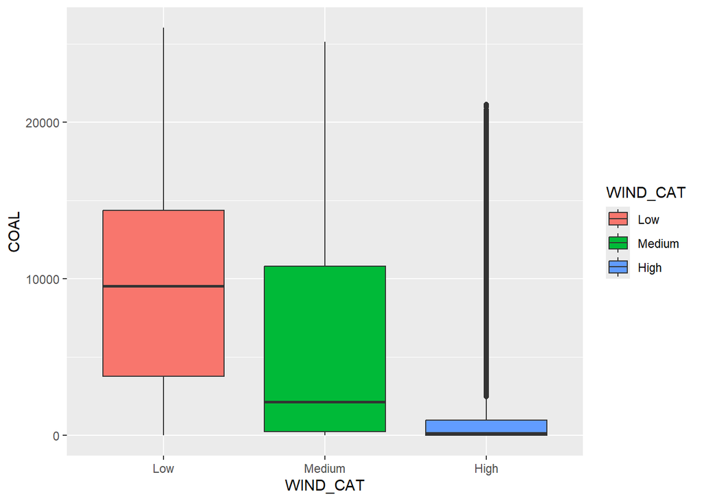

```r
ggplot(df_fuel_ckan, aes(x = WIND_CAT, y = COAL, fill = WIND_CAT)) +
  geom_boxplot()
```

### Diagram 8: Carbon intensity

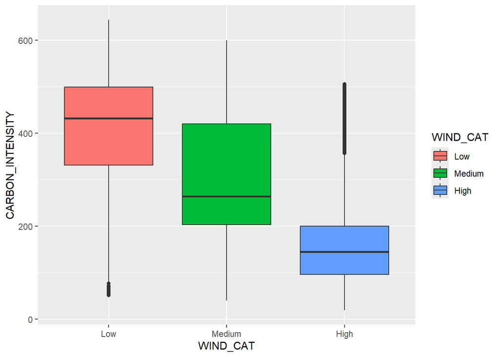

```r
ggplot(df_fuel_ckan, aes(x = WIND_CAT, y = CARBON_INTENSITY, fill = WIND_CAT)) +
  geom_boxplot()
```

### Diagram 9: Gas boxplot

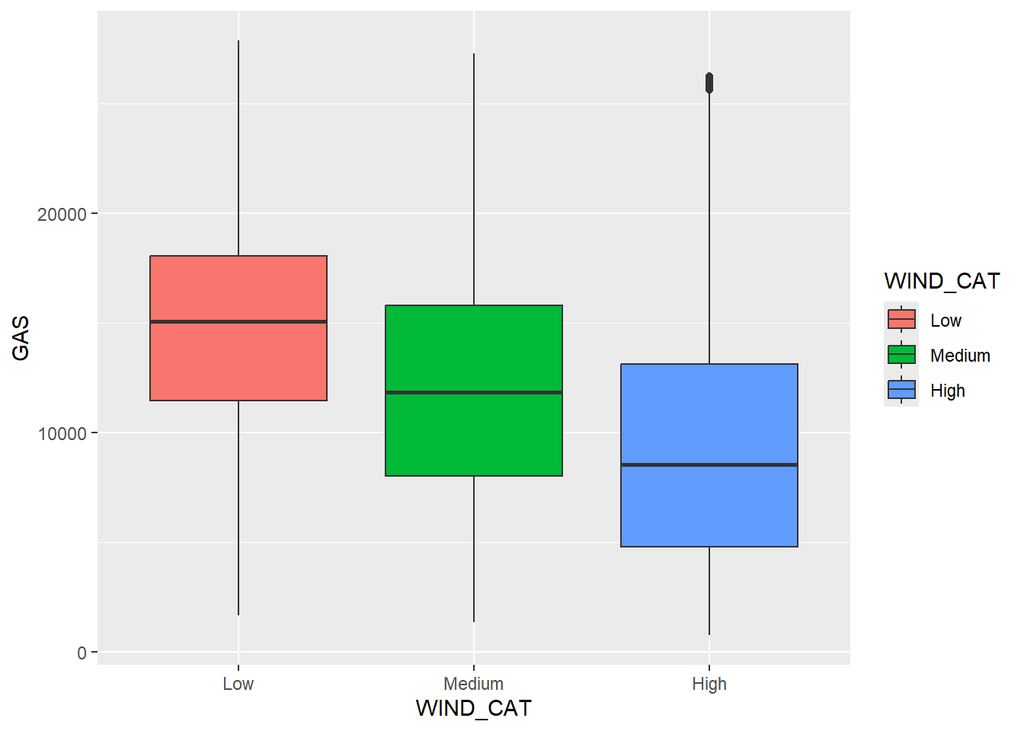

```r
ggplot(df_fuel_ckan, aes(x = WIND_CAT, y = GAS, fill = WIND_CAT)) +
  geom_boxplot()
```

Boxplots were used to compare distributions across wind categories, visually confirming reductions in carbon intensity, coal, and gas as wind increases

## 11. Scenario Analysis

### Diagram 10 :

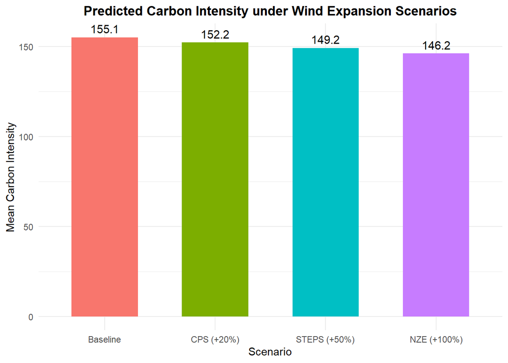

```r
# Baseline prediction
pred_baseline <- predict(model_xgb, x_test)

# CPS scenario: +20% wind


scenario_cps <- test
scenario_cps$WIND <- scenario_cps$WIND * 1.2
pred_cps <- predict(
  model_xgb,
  as.matrix(scenario_cps[, c("WIND","SOLAR","COAL","GAS","HYDRO","GENERATION")])
)


# STEPS scenario: +50% wind


scenario_steps <- test
scenario_steps$WIND <- scenario_steps$WIND * 1.5
pred_steps <- predict(
  model_xgb,
  as.matrix(scenario_steps[, c("WIND","SOLAR","COAL","GAS","HYDRO","GENERATION")])
)


# NZE scenario: +100% wind

scenario_nze <- test
scenario_nze$WIND <- scenario_nze$WIND * 2
pred_nze <- predict(
  model_xgb,
  as.matrix(scenario_nze[, c("WIND","SOLAR","COAL","GAS","HYDRO","GENERATION")])
)


# Summary table

scenario_results <- data.frame(
  Scenario = c("Baseline", "CPS (+20%)", "STEPS (+50%)", "NZE (+100%)"),
  Mean_Carbon_Intensity = c(
    mean(pred_baseline),
    mean(pred_cps),
    mean(pred_steps),
    mean(pred_nze)
  )
)


#Scenario Result


scenario_results$Scenario <- factor(
  scenario_results$Scenario,
  levels = c("Baseline", "CPS (+20%)", "STEPS (+50%)", "NZE (+100%)")
)


ggplot(scenario_results, aes(x = Scenario, y = Mean_Carbon_Intensity, fill = Scenario)) +
  geom_col(width = 0.6) +
  geom_text(aes(label = round(Mean_Carbon_Intensity, 1)), vjust = -0.5, size = 4) +
  theme_minimal() +
  labs(
    title = "Predicted Carbon Intensity under Wind Expansion Scenarios",
    x = "Scenario",
    y = "Mean Carbon Intensity"
  ) +
  theme(
    legend.position = "none",
    plot.title = element_text(hjust = 0.5, face = "bold")
  )
```

## 12. Conclusion

This study provides clear evidence that increased wind energy generation helps reduce carbon intensity. Key findings include:

. Strong inverse relationship: Exploratory analysis, statistical tests and modelling consistently show that higher levels of wind generation are associated with lower emission intensity. Strong negative relationship between wind and carbon intensity, supported by correlation analysis, Chi-square, ANOVA and Tukey tests, all confirm that wind energy is an important driver in reducing carbon emissions.

. Partial substitute for fossil fuel: The findings also indicate that wind energy can partly displace fossil fuel generation, mainly coal and to a lesser extent, gas. This simply means that an increase in wind output not only cuts emissions directly but also reduces dependencies on high-carbon sources.

. Superior model performance: From the predictive analysis, the XGBoost machine learning model outperformed the linear regression model and the Random Forest model, with XGBoost achieving the highest accuracy of 10.53652. A sample of 30000 observations was used for Random Forest to reduce computational cost while preserving model performance.

. Scenario-based Insight: Scenario analysis shows that as wind generation increases; it leads to a consistent reduction in predicted carbon intensity.

Overall, the study reinforces the importance of expanding wind energy to support long-term decarbonisation and progress towards net-zero goals.